# Optimal selection players Gouden 11

# Goal

Goal is to find an optimal selection of players for Gouden 11. We’ll start with a strategy of randomly picking players and then try to improve on that strategy by having a look at the most valuable players and see if they have any characteristics we can exploit. To have a benchmark against which to judge our strategy, we’ll compare our selections to the selections chosen by real users.

```r
# clean environment
rm(list = ls())

# packages
library(ggplot2)
library(dplyr)
library(purrr)
library(ggpubr)
# load data
players <- read.csv(file = "../extract/csv/players.csv", as.is = (c("name")))
formations_used <- read.csv(file = "../extract/csv/formations_used_top_users.csv", header = FALSE)
total_points_real_teams <- read.csv(file = "../extract/csv/points_teams_top_users.csv")

# load functions
source("lib/randomly_select_players.R")
source("lib/check_restrictions.R")
source("lib/calculate_total_points_teams.R")
```

```r
players <- players %>%
  mutate(roi = points/value) # calculate roi
```

# All restrictions

## How to score points

Players score points for goals scored, clean sheets, … Read the rules if you want the details.

## The restrictions

- select 15 players (11 starting squad, 4 replacements)
- each game you can swap players between the starting squad and replacements
- max total value of 250M
- max 2 players of the same team
- use one of the predefined formations
- one of the starting players is a captain scoring 1.5 times the number of points
- 6 total transfers can be made over the entire season

## Some restrictions are more complicated to handle than others

Of these restrictions the following are variable:

- choice of captain
- transfers
- making replacements

Since complications arise out of those variable restrictions we won’t focus on them in a preliminary analysis.

# Restrictions to focus on

The restrictions make clear there are 3 main factors for us to take into account:

- value (max of 250M)
- position (max of x players in position y depending on formation)
- club (max 2 players of the same team)

## Possible formations

The problem with the formations is they are not explicitly defined in the rules. The best way to find out what formations are possible is to have a look at the formations used by existing users.

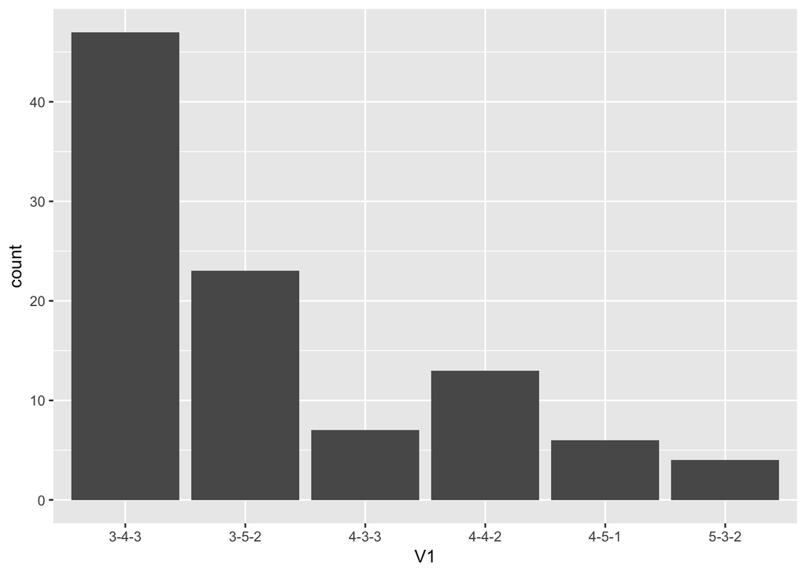

```r
ggplot(data = formations_used, aes(x = V1)) + geom_bar()
```

As the graph shows there are 6 possible formations:

- 3-4-3
- 3-5-2
- 4-3-3
- 4-4-2
- 4-5-1
- 5-3-2

3-4-3 is clearly the most popular one with about half of the top 100 users using that formation. This might be a strong indication this is also the best formation.

## Find the optimum

Regarding solutions, this looks like a lineair programming problem but let’s first try to handle this manually. We just select teams randomly and filter out those teams meeting our restrictions.

# Random selection of players

Since the previous part showed the most used formation is 3-4-3 we’ll select 1 keeper, 3 defenders, 4 midfielders and 3 attackers. We don’t care about replacements so we just select 11 players. Let’s select 10000 teams.

```r
random_teams_all_players <- replicate(10000,
                                      randomly_select_players(players,3,4,3),
                                      simplify = FALSE)
```

Now we can check if each randomly selected team:

- has a value less or equal than 250M
- doesn’t have more than 2 players of the same team

```r
random_teams_all_players <- random_teams_all_players %>% # overwrite to save memory
  map(filter_out_violating_team) %>%
  discard(is.null) # NULL is violating team
```

# Compare total points random teams with teams by real users

Let’s see how well these random teams did compared to the teams selected by real users. We randomly select a captain as well.

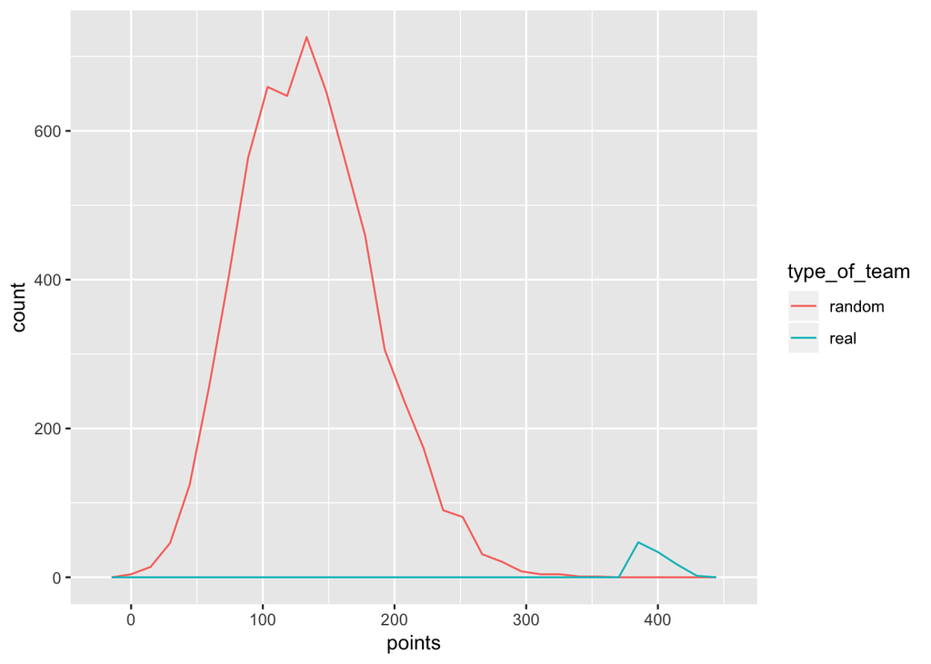

```r
total_points_random_teams <- calculate_total_points_teams(random_teams_all_players) %>%
                                  mutate(type_of_team = "random")
total_points_real_teams <- total_points_real_teams %>%
                                  mutate(type_of_team = "real") %>%
                                  select(points, type_of_team)

total_points_teams <- bind_rows(total_points_random_teams,
                                total_points_real_teams)

ggplot(data = total_points_teams,
       aes(x = points, colour = type_of_team)) +
  geom_freqpoly()
```

It’s clear there’s almost no overlap between the random teams and real teams. This means we’ll have to improve on our strategy. A good way to start is by looking at what players have a high return on investment (points/value) and see if they belong to specific clubs.

# What are the valuable players?

Let’s plot the roi for the top 50 players with the hightest roi and see to what teams they belong.

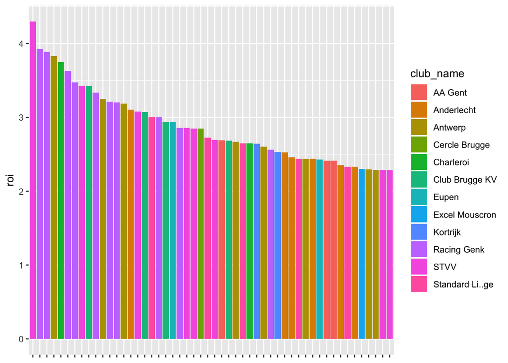

```r
top_50_players_by_roi <- players %>%
  top_n(50, roi)

ggplot(data = top_50_players_by_roi,
       aes(x = reorder(name, -roi),
           y = roi,
           fill = club_name)) +
  geom_col() +
  ggpubr::rremove("x.text") +
  ggpubr::rremove("x.title")
```

It seems all the most valued players are in teams that have a good spot in the league table. If we can predict at the beginning of the season what teams will be high in the league table we can seriously limit our selection. STVV and Antwerp are the odd ones here and would be difficult to predict beforehand. On the other hand Anderlecht, Club Brugge,… are the usual suspects.

# Random selection of players within top teams last season

Let’s redo the picking of players but this time we only keep players of one of the 6 most high ranking teams of last season (2017-2018).

This is the final league of the season 2017-2018:

1. Club Brugge
2. Standard de Liège
3. Anderlecht
4. Gent
5. Genk
6. Charleroi

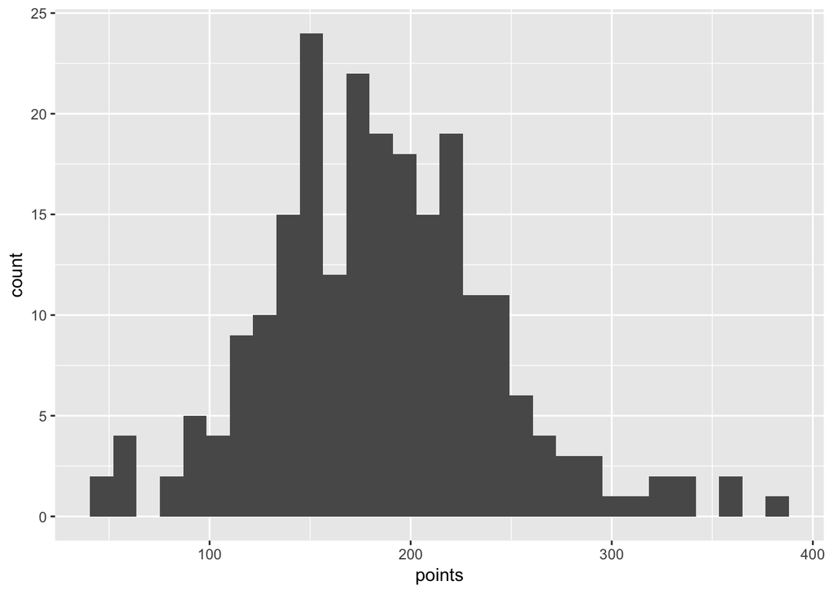

```r
# only take players from top teams last year into account
players_top_teams <- players %>% filter(club_name %in% c("Club Brugge KV",
                                                         "Standard Li\303\250ge",
                                                         "Anderlecht",
                                                         "AA Gent",
                                                         "Racing Genk",
                                                         "Charleroi"))

# select random teams
random_teams_top_players <- replicate(10000,
                                      randomly_select_players(players_top_teams,
                                                              3,
                                                              4,
                                                              3),
                                      simplify = FALSE)

random_teams_top_players <- random_teams_top_players %>% map(filter_out_violating_team) %>% discard(is.null)

# calculate total points by team
total_points_random_teams_top_players <- calculate_total_points_teams(random_teams_top_players)

# plot histogram total points by team
ggplot(data = total_points_random_teams_top_players,
       aes(x = points)) +
  geom_histogram()
```

We randomly select 10000 teams of which roughly 250 are valid. Unfortunately, our highest ranking team scores less than 400 points which would obtain around place 100.

# Conclusion

It doesn’t seem to be possible to get at least a high ranking team using the strategy described above. However, we didn’t take advantage of the following:

- alternative formations
- replacement players
- transfers
- selecting a captain

By manually making replacements and transfers at the right time and selecting a captain you’d probably get more points.